# Assignment_Week1

Adam Peetz  
MSDS660 Week 1 Assignment  
Regis University  
Dr. Siripun Sanguansintukul  
October 23rd 2022

# Exploratory Data Analysis of Marketing Data

Targeted marketing can increase a company’s sales, bridging the gap between items on sale and a customer’s current needs. To effectively target marketing, a company must understand its customer’s purchasing behavior. One way to gain this understanding is to conduct a statistical analysis of a company’s sales data. This type of exploratory data analysis can illustrate connections between customer demographics and potential future sales.

A marketing data set provided by Hult International Business School will be used to demonstrate exploratory data analysis of sales and demographic information in the cells below.

First set the working directory, load the required libraries, and import the data set.

## Set Working Directory

```r
#set working directory
setwd("C:\\Users\\adamg\\Documents\\MSDS_660\\Week_1")
```

## Load Libraries

```r
library (tidyverse)
library(data.table)
library(dplyr)
library(ggplot2)
#install.packages("hexbin")
library(hexbin)
```

## Load Data

```r
df<-read_csv("marketing.csv")
```

## Convert to data.table

```r
#convert to data.table
setDT(df)
```

## Explore the raw data with str().

Checking the data frame with str() reveals some basic information about the data it contains. Useful info provided by this function includes the variable names, column contents, and types for each of the 19 variables in the data set.

```r
#Check what you have with str
str(df)
```

```
## Classes 'data.table' and 'data.frame':   2240 obs. of  19 variables:
##  $ ID                 : num  1826 1 10476 1386 5371 ...
##  $ Year_Birth         : num  1970 1961 1958 1967 1989 ...
##  $ Education          : chr  "Graduation" "Graduation" "Graduation" "Graduation" ...
##  $ Marital_Status     : chr  "Divorced" "Single" "Married" "Together" ...
##  $ Income             : chr  "$84,835.00" "$57,091.00" "$67,267.00" "$32,474.00" ...
##  $ Kidhome            : num  0 0 0 1 1 0 0 0 0 0 ...
##  $ Dt_Customer        : chr  "6/16/2014" "6/15/2014" "5/13/2014" "5/11/2014" ...
##  $ MntWines           : num  189 464 134 10 6 336 769 78 384 384 ...
##  $ MntFruits          : num  104 5 11 0 16 130 80 0 0 0 ...
##  $ MntMeatProducts    : num  379 64 59 1 24 411 252 11 102 102 ...
##  $ MntFishProducts    : num  111 7 15 0 11 240 15 0 21 21 ...
##  $ MntSweetProducts   : num  189 0 2 0 0 32 34 0 32 32 ...
##  $ MntGoldProds       : num  218 37 30 0 34 43 65 7 5 5 ...
##  $ NumDealsPurchases  : num  1 1 1 1 2 1 1 1 3 3 ...
##  $ NumWebPurchases    : num  4 7 3 1 3 4 10 2 6 6 ...
##  $ NumCatalogPurchases: num  4 3 2 0 1 7 10 1 2 2 ...
##  $ NumStorePurchases  : num  6 7 5 2 2 5 7 3 9 9 ...
##  $ Response           : num  1 1 0 0 1 1 1 0 0 0 ...
##  $ Country            : chr  "SP" "CA" "US" "AUS" ...
##  - attr(*, "spec")=
##   .. cols(
##   ..   ID = col_double(),
##   ..   Year_Birth = col_double(),
##   ..   Education = col_character(),
##   ..   Marital_Status = col_character(),
##   ..   Income = col_character(),
##   ..   Kidhome = col_double(),
##   ..   Dt_Customer = col_character(),
##   ..   MntWines = col_double(),
##   ..   MntFruits = col_double(),
##   ..   MntMeatProducts = col_double(),
##   ..   MntFishProducts = col_double(),
##   ..   MntSweetProducts = col_double(),
##   ..   MntGoldProds = col_double(),
##   ..   NumDealsPurchases = col_double(),
##   ..   NumWebPurchases = col_double(),
##   ..   NumCatalogPurchases = col_double(),
##   ..   NumStorePurchases = col_double(),
##   ..   Response = col_double(),
##   ..   Country = col_character()
##   .. )
##  - attr(*, "problems")=<externalptr>
##  - attr(*, ".internal.selfref")=<externalptr>
```

## Summary() for descriptive statistics.

```r
#show statistical summary of features
summary(df)
```

```
##        ID          Year_Birth    Education         Marital_Status
##  Min.   :    0   Min.   :1893   Length:2240        Length:2240
##  1st Qu.: 2828   1st Qu.:1959   Class :character   Class :character
##  Median : 5458   Median :1970   Mode  :character   Mode  :character
##  Mean   : 5592   Mean   :1969
##  3rd Qu.: 8428   3rd Qu.:1977
##  Max.   :11191   Max.   :1996
##     Income             Kidhome       Dt_Customer           MntWines
##  Length:2240        Min.   :0.0000   Length:2240        Min.   :   0.00
##  Class :character   1st Qu.:0.0000   Class :character   1st Qu.:  23.75
##  Mode  :character   Median :0.0000   Mode  :character   Median : 173.50
##                     Mean   :0.4442                      Mean   : 303.94
##                     3rd Qu.:1.0000                      3rd Qu.: 504.25
##                     Max.   :2.0000                      Max.   :1493.00
##    MntFruits     MntMeatProducts  MntFishProducts  MntSweetProducts
##  Min.   :  0.0   Min.   :   0.0   Min.   :  0.00   Min.   :  0.00
##  1st Qu.:  1.0   1st Qu.:  16.0   1st Qu.:  3.00   1st Qu.:  1.00
##  Median :  8.0   Median :  67.0   Median : 12.00   Median :  8.00
##  Mean   : 26.3   Mean   : 166.9   Mean   : 37.53   Mean   : 27.06
##  3rd Qu.: 33.0   3rd Qu.: 232.0   3rd Qu.: 50.00   3rd Qu.: 33.00
##  Max.   :199.0   Max.   :1725.0   Max.   :259.00   Max.   :263.00
##   MntGoldProds    NumDealsPurchases NumWebPurchases  NumCatalogPurchases
##  Min.   :  0.00   Min.   : 0.000    Min.   : 0.000   Min.   : 0.000
##  1st Qu.:  9.00   1st Qu.: 1.000    1st Qu.: 2.000   1st Qu.: 0.000
##  Median : 24.00   Median : 2.000    Median : 4.000   Median : 2.000
##  Mean   : 44.02   Mean   : 2.325    Mean   : 4.085   Mean   : 2.662
##  3rd Qu.: 56.00   3rd Qu.: 3.000    3rd Qu.: 6.000   3rd Qu.: 4.000
##  Max.   :362.00   Max.   :15.000    Max.   :27.000   Max.   :28.000
##  NumStorePurchases    Response        Country
##  Min.   : 0.00     Min.   :0.0000   Length:2240
##  1st Qu.: 3.00     1st Qu.:0.0000   Class :character
##  Median : 5.00     Median :0.0000   Mode  :character
##  Mean   : 5.79     Mean   :0.1491
##  3rd Qu.: 8.00     3rd Qu.:0.0000
##  Max.   :13.00     Max.   :1.0000
```

## More descriptive outputs with head().

The head function() displays the top rows of the data set. It is useful for visualizing the raw data.

```r
#display file header into
head(df,6)
```

| ID | Year_Birth | Education | Marital_Status | Income | Kidhome | Dt_Customer | MntWines | MntFruits | MntMeatProducts | MntFishProducts | MntSweetProducts | MntGoldProds | NumDealsPurchases | NumWebPurchases | NumCatalogPurchases | NumStorePurchases | Response | Country |
| --- | --- | --- | --- | --- | --- | --- | --- | --- | --- | --- | --- | --- | --- | --- | --- | --- | --- | --- |
| 1826 | 1970 | Graduation | Divorced | $84,835.00 | 0 | 6/16/2014 | 189 | 104 | 379 | 111 | 189 | 218 | 1 | 4 | 4 | 6 | 1 | SP |
| 1 | 1961 | Graduation | Single | $57,091.00 | 0 | 6/15/2014 | 464 | 5 | 64 | 7 | 0 | 37 | 1 | 7 | 3 | 7 | 1 | CA |
| 10476 | 1958 | Graduation | Married | $67,267.00 | 0 | 5/13/2014 | 134 | 11 | 59 | 15 | 2 | 30 | 1 | 3 | 2 | 5 | 0 | US |
| 1386 | 1967 | Graduation | Together | $32,474.00 | 1 | 5/11/2014 | 10 | 0 | 1 | 0 | 0 | 0 | 1 | 1 | 0 | 2 | 0 | AUS |
| 5371 | 1989 | Graduation | Single | $21,474.00 | 1 | 4/8/2014 | 6 | 16 | 24 | 11 | 0 | 34 | 2 | 3 | 1 | 2 | 1 | SP |
| 7348 | 1958 | PhD | Single | $71,691.00 | 0 | 3/17/2014 | 336 | 130 | 411 | 240 | 32 | 43 | 1 | 4 | 7 | 5 | 1 | SP |

## Find how many countries are represented in the data.

The dataset contains 8 countries: AUS, CA, GER, IND, ME, SA, SP, US.

```r
#unique count of specific feature
length(unique(df$Country))
```

```
## [1] 8
```

## Can you sort by the name of the country?

```r
df[order(df[,'Country']), ]
```

| ID | Year_Birth | Education | Marital_Status | Income | Kidhome | Dt_Customer | MntWines | MntFruits | MntMeatProducts | MntFishProducts | MntSweetProducts | MntGoldProds | NumDealsPurchases | NumWebPurchases | NumCatalogPurchases | NumStorePurchases | Response | Country |
| --- | --- | --- | --- | --- | --- | --- | --- | --- | --- | --- | --- | --- | --- | --- | --- | --- | --- | --- |
| 1386 | 1967 | Graduation | Together | $32,474.00 | 1 | 5/11/2014 | 10 | 0 | 1 | 0 | 0 | 0 | 1 | 1 | 0 | 2 | 0 | AUS |
| 5824 | 1972 | PhD | Together | $34,578.00 | 2 | 4/11/2014 | 7 | 0 | 1 | 0 | 0 | 0 | 1 | 1 | 0 | 2 | 0 | AUS |
| 5114 | 1965 | Master | Married | $74,806.00 | 0 | 12/19/2012 | 670 | 9 | 249 | 0 | 28 | 9 | 2 | 5 | 4 | 5 | 0 | AUS |
| 4865 | 1974 | Master | Divorced | $53,367.00 | 1 | 8/31/2013 | 229 | 7 | 140 | 10 | 3 | 11 | 7 | 5 | 1 | 8 | 1 | AUS |
| 4405 | 1956 | Master | Married | $63,915.00 | 0 | 7/30/2013 | 622 | 7 | 115 | 30 | 0 | 15 | 2 | 6 | 3 | 12 | 0 | AUS |
| 4114 | 1964 | Master | Married | $79,143.00 | 0 | 8/11/2012 | 650 | 37 | 780 | 27 | 167 | 32 | 1 | 6 | 9 | 13 | 0 | AUS |
| 4098 | 1973 | Graduation | Married | $24,639.00 | 1 | 1/28/2014 | 20 | 3 | 16 | 0 | 4 | 1 | 3 | 2 | 0 | 4 | 0 | AUS |
| 8601 | 1980 | Graduation | Married | $80,011.00 | 0 | 4/29/2013 | 421 | 76 | 536 | 82 | 178 | 102 | 2 | 8 | 6 | 5 | 0 | AUS |
| 2534 | 1953 | Graduation | Married | $37,716.00 | 0 | 4/21/2014 | 97 | 1 | 41 | 6 | 2 | 41 | 2 | 4 | 1 | 3 | 0 | AUS |
| 8755 | 1946 | Master | Married | $68,657.00 | 0 | 2/20/2013 | 482 | 34 | 471 | 119 | 68 | 22 | 1 | 3 | 5 | 9 | 0 | AUS |

[output cut: 2230 more lines]

## Find mean and sd of in-store purchases in the US.

The mean and standard deviation for all countries can be found by grouping the data set by country and setting up an aggregation summary for mean and standard deviation. The mean of in store purchases for the US is 6.03, the standard deviation is 3.36. The statistics for all 8 countries are shown in the table below.

```r
analysis_df_1 <- df %>%
  group_by(Country) %>%
  summarize(mean = mean(NumStorePurchases),
            sd = sd(NumStorePurchases))

analysis_df_1
```

| Country | mean | sd |
| --- | --- | --- |
| AUS | 5.493750 | 3.170217 |
| CA | 5.850746 | 3.182366 |
| GER | 6.008333 | 3.369402 |
| IND | 5.304054 | 3.212770 |
| ME | 6.333333 | 2.081666 |
| SA | 5.899110 | 3.201827 |
| SP | 5.800913 | 3.277618 |
| US | 6.036697 | 3.360794 |

## Data Cleaning

The income feature should be numeric but is treated as a character column due to the use of dollar signs. The dollar signs must be removed so that the column is treated as a numeric value. This column also contains several rows with NA. Rows containing NA will be dropped from the data set to clean up the values in this variable.

```r
#remove NA from column
df<- df[-which(is.na(df$Income)), ]

#remove $ signs
df$Income <- parse_number(df$Income)
```

## Set scientific notation for plotting.

Set scipen to a higher value, to prevent numbers being displayed in scientific notation on future plots.

```r
options(scipen=999)
```

## Histogram of Income

Customer income is included in the demographic information provided by the data set. Plotting the distribution of customer income shows that most of the customers make less than 100,000 dollars with a somewhat standard looking distribution forming between 0 and 100,000. There are a few outliers in the data set with high incomes above this mark. One lucky customer makes 666,666 dollars, or may have lied about their income on the demographic’s questionnaire.

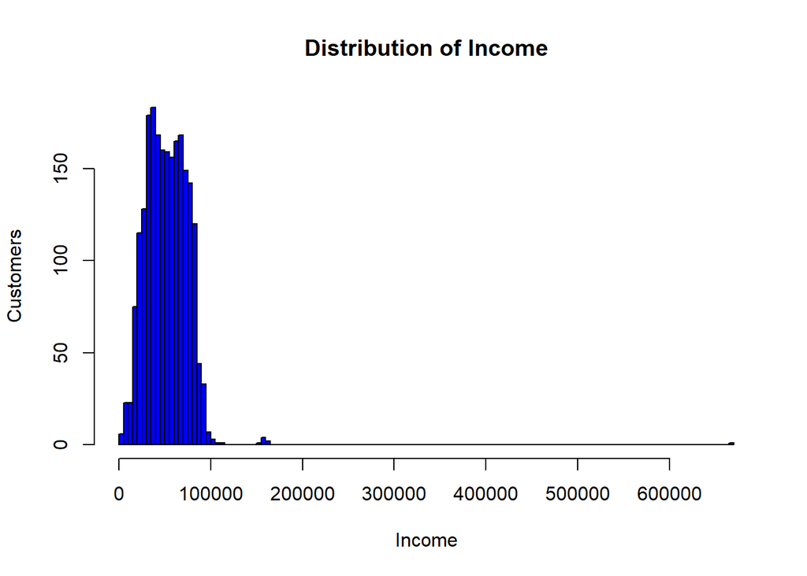

```r
hist(df$Income,
main="Distribution of Income",
xlab="Income",
ylab="Customers",
col="blue",
breaks=100
)
```

## Boxplot of Amount of Sweet Products

Box and whisker plots visualize the distribution of a single feature. They are often used for outlier detection. A boxplot has been created for the amount spent on sweet products in the code below. This boxplot shows that the average customer spends very little on sweet products. The distribution for this variable is skewed to the right towards fewer purchases on sweets. Despite this trend, there are a few outlying customers who spend lots of money on sweets when compared to the average customer in the data set.

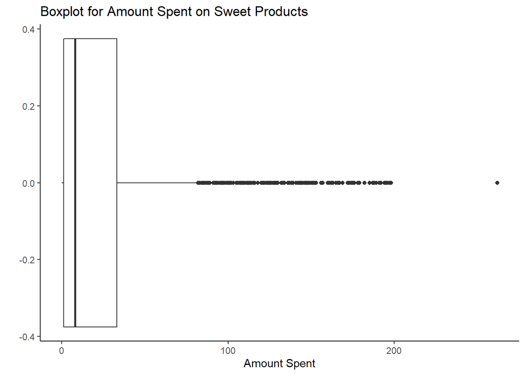

```r
#boxplot of percent in plastic waste
ggplot(df, aes(x=MntSweetProducts))+
  geom_boxplot()+
  ggtitle("Boxplot for Amount Spent on Sweet Products") +
  labs(y= "", x = "Amount Spent")+
  theme_bw() +
  theme(panel.border = element_blank(),
        panel.grid.major = element_blank(),
        panel.grid.minor = element_blank(),
        axis.line = element_line(colour = "black"),
        legend.position="none")
```

## Which country is has the highest amount of wine consumed?

The country with the highest amount of wine consumed in the data set is Spain, with a total spend amount over 300,000 dollars. The wine consumed by all 8 countries is visualized by the code below.

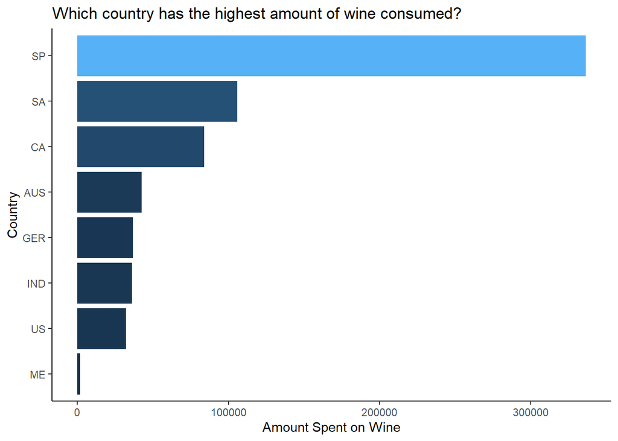

```r
#create grouped analysis dataframe for sum/total
analysis_df_2 <- df %>%
  group_by(Country) %>%
  summarize(total = sum(MntWines))

#draw vertical histogram
ggplot(analysis_df_2, aes(x=fct_reorder(Country,total), y=total,fill=total))+
  geom_bar(stat='identity')+
  coord_flip() +
  ggtitle("Which country has the highest amount of wine consumed?") +
  labs(y= "Amount Spent on Wine", x = "Country")+
  theme_bw() +
  theme(panel.border = element_blank(),
        panel.grid.major = element_blank(),
        panel.grid.minor = element_blank(),
        axis.line = element_line(colour = "black"),
        legend.position="none")
```

## Feature Engineering

Two new features will be created for the data set. Total amount spent between all purchase categories and total sales count from all distribution types. These two features will be combined with demographic information later in the code to evaluate who are the best customers in the data set.

```r
#create totalpsum variable
df$totalpsum <- df$NumStorePurchases +
                df$NumWebPurchases +
                df$NumCatalogPurchases

#test variable creation
summary(df$totalpsum)
```

```
##    Min. 1st Qu.  Median    Mean 3rd Qu.    Max.
##    0.00    6.00   12.00   12.56   18.00   32.00
```

```r
#create totalpmnt variable
df$totalpmnt<- df$MntWines +
               df$MntFruits +
               df$MntFishProducts +
               df$MntSweetProducts +
               df$MntGoldProds  +
               df$MntMeatProducts

#test variable creation
summary(df$totalpmnt)
```

```
##    Min. 1st Qu.  Median    Mean 3rd Qu.    Max.
##     5.0    69.0   396.5   607.1  1048.0  2525.0
```

## Take a look at the education variable and see what it looks like.

Education is included as a demographic variable in the data set. About half of the company’s customers are at “graduation” level, followed by PhD. A bar plot and table are generated for this variable below.

```r
#create grouped analysis dataframe with count
analysis_df_3 <- df %>%
  group_by(Education) %>%
  summarize(Count = n())

print(analysis_df_3)
```

```
## # A tibble: 5 × 2
##   Education  Count
##   <chr>      <int>
## 1 2n Cycle     200
## 2 Basic         54
## 3 Graduation  1116
## 4 Master       365
## 5 PhD          481
```

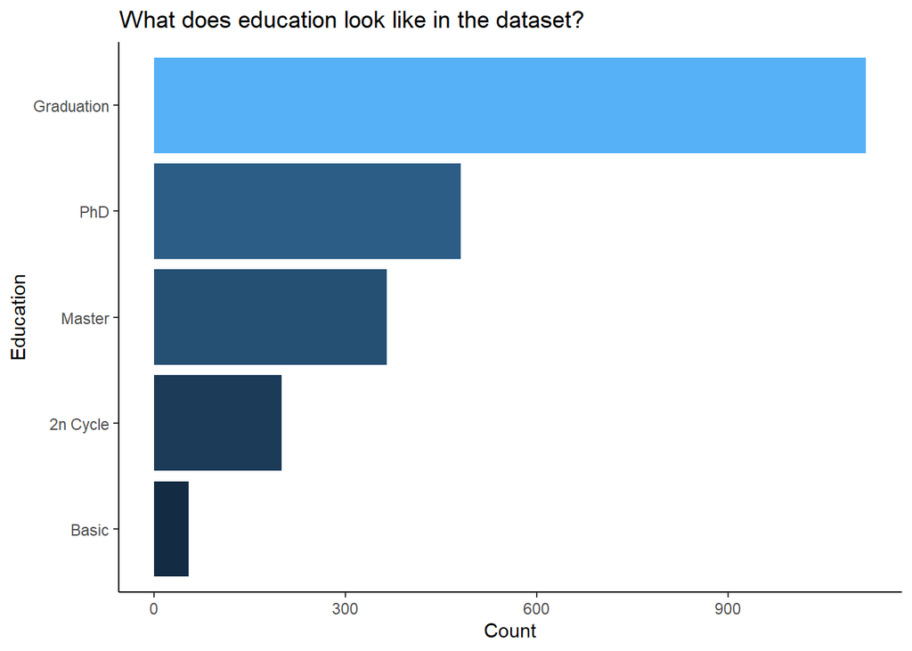

```r
#draw vertical barplot
ggplot(analysis_df_3, aes(x=fct_reorder(Education, Count), y=Count,fill=Count))+
  geom_bar(stat='identity')+
  coord_flip() +
  ggtitle("What does education look like in the dataset?") +
  labs(y= "Count", x = "Education")+
  theme_bw() +
  theme(panel.border = element_blank(),
        panel.grid.major = element_blank(),
        panel.grid.minor = element_blank(),
        axis.line = element_line(colour = "black"),
        legend.position="none")
```

## Hued Facet Scatterplots with Trendlines

Hued, faceted, scatter plots with trend lines are a powerful tool for visualizing the relationship and effect of many variables in parallel. An example of this type of plot is shown for total payment amount, total sale count, education, and response to promotion offer below. Some patterns that pop out are:  
- There are very few sales made to the basic education facet, most of these sales are low payment amount and low sale count.  
- Customers with high total payment amount and high total sale count are more likely to respond to a promotion offer.  
- There is a bump in the trend line for total sale count and total payment amount. Customers with the highest sale count spend less per sale.

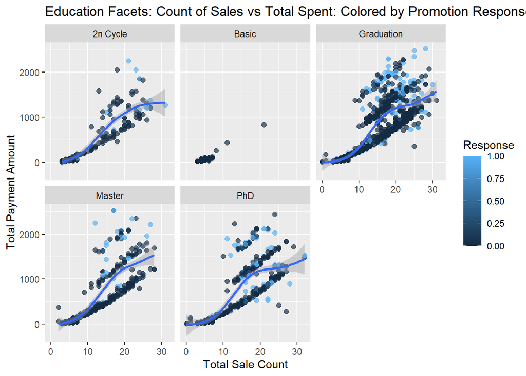

```r
p <- ggplot(df, aes(x = totalpsum, y = totalpmnt))
p +  geom_point(alpha = (2/3), size = 2,aes(color = Response)) +
     geom_smooth() +
     ggtitle("Education Facets: Count of Sales vs Total Spent: Colored by Promotion Response") +
     labs(y= "Total Payment Amount", x = "Total Sale Count")+
     facet_wrap(~ Education)
```

## Create hexplot to show density of correlating features.

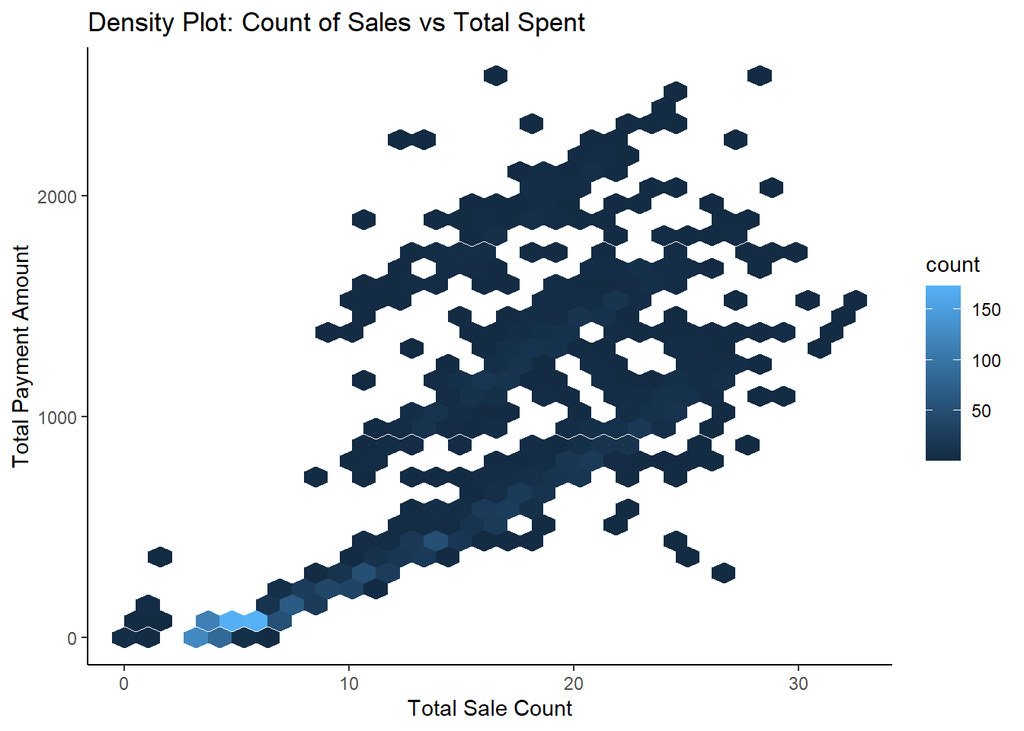

```r
#create grouped analysis dataframe
p <- ggplot(df, aes(x = totalpsum, y = totalpmnt))
p +  geom_hex() +
     ggtitle("Density Plot: Count of Sales vs Total Spent") +
     labs(y= "Total Payment Amount", x = "Total Sale Count")+
     theme_bw() +
     theme(panel.border = element_blank(),
           panel.grid.major = element_blank(),
           panel.grid.minor = element_blank(),
           axis.line = element_line(colour = "black"))
```

## Export dataset to CSV

The data set can be saved to a csv file for future use with the write_csv() function.

```r
#write_csv export data out
write_csv(df, "cleaned_marketing_data.csv")
```

# Conclusion

Exploratory analysis of the marketing data set revealed some insights on customer types and purchases. This company’s customers are usually well educated, with “graduation” level customers making up most of the customers in the data set. The company’s best customers (in terms of total sales count and amount) are also those who respond to promotions, with many high spenders having responded to a promotion in the data set. The company may want to target promotions towards return customers for items they purchase frequently to stimulate more sales.

There are many additional types of analysis that could be performed with this data set to gain insight into the company’s customers. A recommendation for future research is to understand what regional differences exist between purchase types. This analysis could be performed with additional hued, faceted, scatter plots as demonstrated with the education variable above. Understanding regional purchase patterns would allow the company to tailor its product mix geographically, which would improve sales in those regions. It may also reveal new trends in the dataset that are not easy to recognize with intuition alone.

# References

Bryan, Jennifer. (2017). *ggplot2-tutorial* . github.com. retrieved 10/22/22 from https://github.com/jennybc/ggplot2-tutorial

Hult International Business School. (n.d.). *marketing data* . dataset. retrieved 10/22/22 from https://worldclass.regis.edu/d2l/le/content/297311/Home